# 556TermProject_Proposal

Author

Callan, Abbie, and Katie - ENV H 556

This document was rendered on October 23, 2024.

## Setting up

For our term project, we aim to assess the temporal variations of traffic-related air pollution (TRAP). Specifically, we will assess how air pollution levels vary across seasons, days of the week, or hours of the day. Our project will use data from the Mobile Monitoring Campaign, as described by [Blanco et al.](https://pubmed.ncbi.nlm.nih.gov/35917479/).

## Introduction

*Introduction to Mobile Monitoring Data set and variables* The Mobile Monitoring dat set comes from a study of air pollution and its association with aging. The study collected air samples from around the greater Seattle area (Washington, United States). A car, equipped with air quality monitoring and sampling equipment, drove along nine routes, stopping and taking ~ 309 samples across all nine routes. Each sample is a two-minute sample of air quality, including pollutant concentrations for nitrogen dioxide (NO2), PM2.5, particle number concentration (PNC), carbon dioxide (CO2), and black carbon (BC). This air sample data was used to associate with ageing outcomes in study participants. Our report will not look at any health outcomes, and will focus on characterizing the temporal patterns in the air pollution data.

Over the course of a year, each site along the nine driving routes was visited about 25 times [Blanco et al., 2022].

Specific Stop-level Data

*specific aims/hypotheses*

The sampling design for the Mobile Monitoring data set included variability in the day time, week, and season that samples were taken for a particular site. This means that each sampling location has sampling data spanning across distinct days, weeks, and months. Our report will utilize the multiple layers of temporal variation in samples to assess changes in air quality across days of the week and across seasons over the year.

We hypothesize that we will see higher levels of TRAP on weekdays during typical work days (M-F). Further, we anticipate that TRAP concentrations will be lower in the summer due to reduced commuter traffic stemming from summer travels [(LA Times 1990)](https://www.latimes.com/archives/la-xpm-1990-09-04-mn-665-story.html).

## Methods & Statistical Approach

We will describe TRAP by season (Fall, Winter, Spring, Summer) and by day of the week using descriptive summary statistics and figures to visualize the data distributions (e.g. box plots and histograms).

We will use ANOVA models to compare the mean concentration of log-transformed air pollutants across (1) seasons (i.e. Fall, Winter, Spring, and Summer); and (2) days of the week. As part of our day-of-the-week assessment, we will additionally test whether TRAP is associated more broadly with day type (i.e. week day or weekend) using a land-use regression model adjusted for season and distance to major roadways, which we anticipate could be precision variables.

## Exploratory/ Introductory Analysis

Each variable has 309 observations with no missing data for any observations (in the annual summary data).

**Introduction to Sampling Location Annual Average Data**

Table 1.0: Summary Statistics for TRAP Variables

| variable | GM | GSD | AM | ASD |
| --- | --- | --- | --- | --- |
| co2_umol_mol | 430.1 | 1.0 | 430.2 | 6.0 |
| ma200_ir_bc1 | 531.7 | 1.3 | 552.1 | 159.2 |
| no2 | 8.9 | 1.3 | 9.2 | 2.6 |
| ns_total_conc | 9921.7 | 1.3 | 10277.6 | 2988.0 |
| pm2.5_ug_m3 | 4.6 | 1.1 | 4.6 | 0.6 |
| pmdisc_number | 8730.8 | 1.4 | 9321.9 | 4088.9 |
| pnc_noscreen | 6878.5 | 1.3 | 7191.4 | 2388.5 |
| pnc_screen | 3046.2 | 1.3 | 3147.8 | 878.6 |

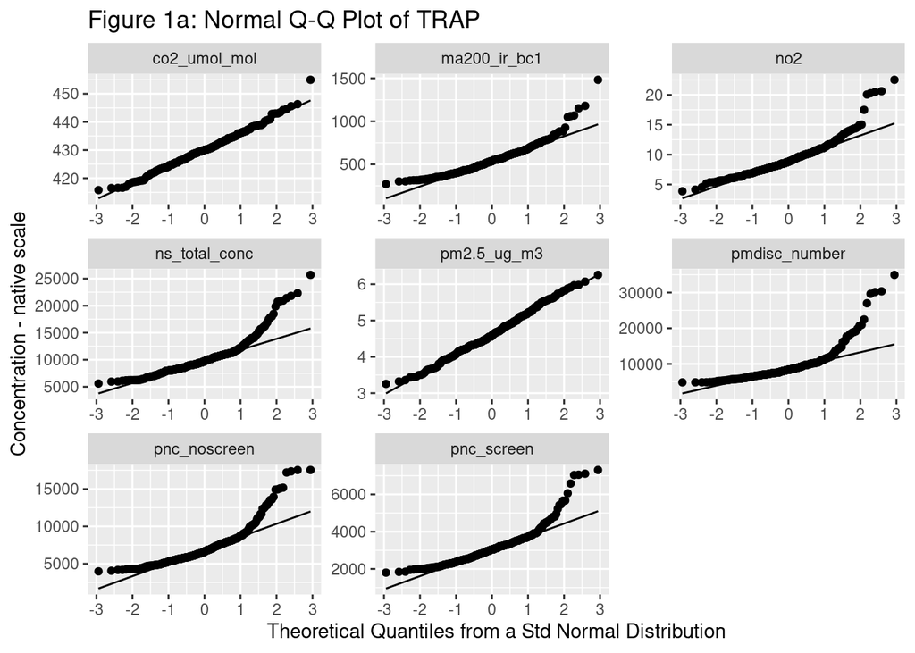

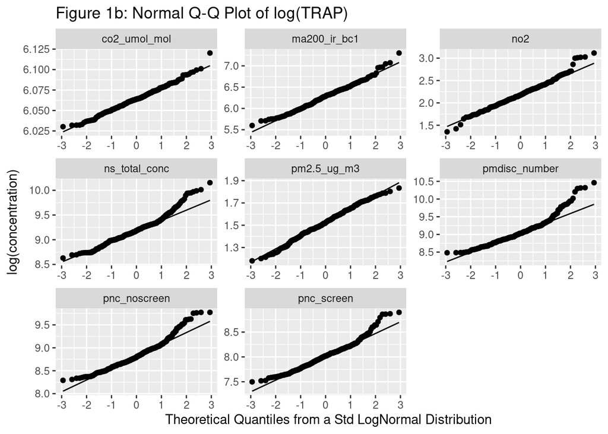

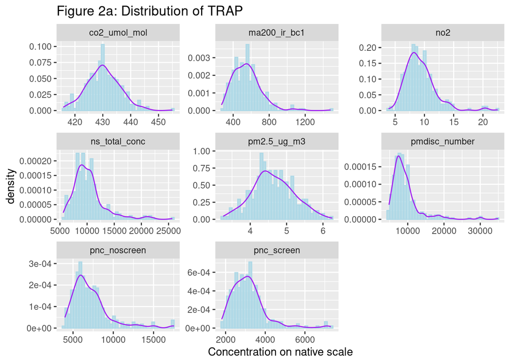

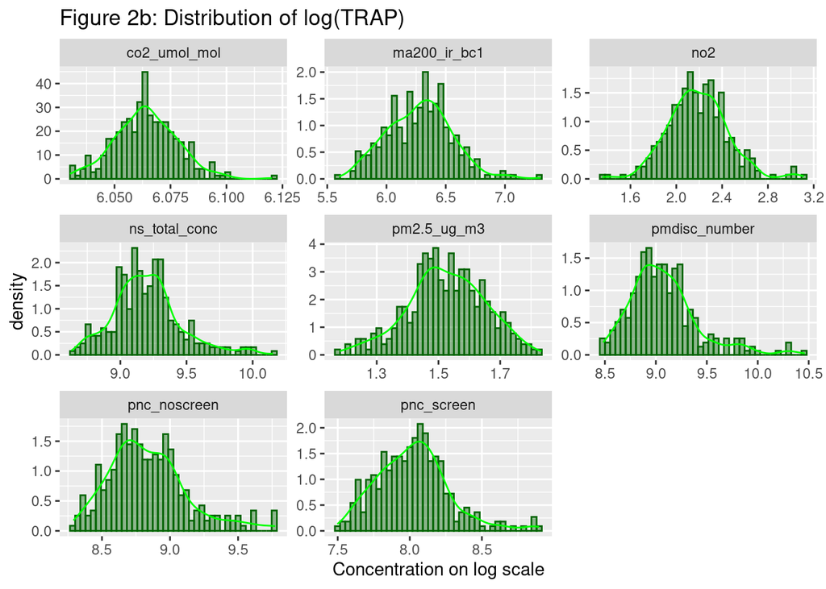

The Histogram plots with smoother in Figures 2a and 2b also indicate a right tailed distribution or skew in most of the TRAP variables.

**Introduction to Stop-Level Data**

| variable | n | nmiss | GM | GSD | AM | ASD |
| --- | --- | --- | --- | --- | --- | --- |
| co2_umol_mol | 8950 | 0 | 430.3 | 1.1 | 430.9 | 23.4 |
| ma200_ir_bc1 | 8860 | 0 | 401.4 | 2.4 | 584.5 | 618.5 |
| neph_bscat | 8786 | 0 | 4.1 | 1.7 | 4.8 | 3.2 |
| no2 | 8747 | 0 | NA | NA | 9.4 | 7.1 |
| ns_total_conc | 8999 | 0 | 8180.0 | 2.1 | 10761.9 | 10820.4 |
| pmdisc_number | 8697 | 0 | 7093.9 | 2.2 | 9889.0 | 14764.9 |
| pnc_noscreen | 8728 | 0 | 5799.4 | 2.0 | 7454.4 | 6506.8 |
| pnc_screen | 8908 | 0 | 2518.5 | 2.1 | 3284.7 | 3315.5 |

```
[1] -0.335023
```

```
[1] "Primary" "Backup"
```

Table 2.0: Stop-Level Data Summary

| variable | n | nmiss | GM | GSD | AM | ASD |
| --- | --- | --- | --- | --- | --- | --- |
| co2_umol_mol | 8950 | 0 | 430.3 | 1.1 | 430.9 | 23.4 |
| ma200_ir_bc1 | 7411 | 0 | 410.2 | 2.4 | 585.7 | 599.3 |
| neph_bscat | 8776 | 0 | 4.1 | 1.7 | 4.8 | 3.2 |
| no2 | 8382 | 0 | 7.1 | 2.3 | 9.5 | 7.1 |
| ns_total_conc | 8808 | 0 | 8277.9 | 2.1 | 10844.6 | 10868.6 |
| pmdisc_number | 5353 | 0 | 7408.5 | 2.3 | 10915.4 | 17672.5 |
| pnc_noscreen | 7792 | 0 | 5725.0 | 2.0 | 7405.1 | 6598.1 |
| pnc_screen | 5085 | 0 | 2568.2 | 1.9 | 3234.9 | 3547.7 |

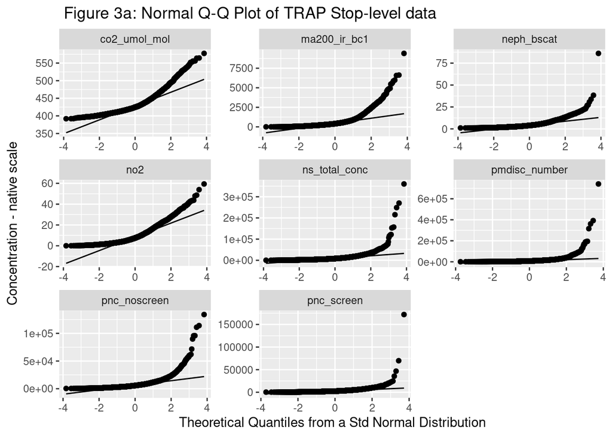

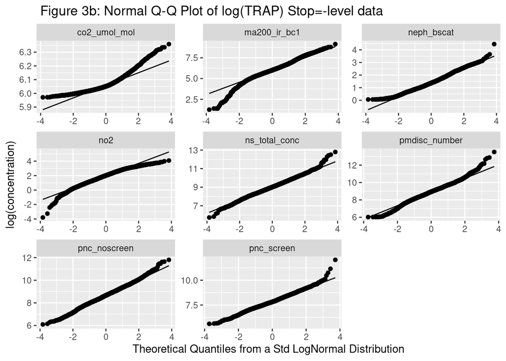

The stop-level data shows similar results as the averaged annual data across sample locations. The data benefits from log transformations and this will likely be what we use in further analysis. CO2 has slightly less normal distribution at stop-level data compared to annual data.

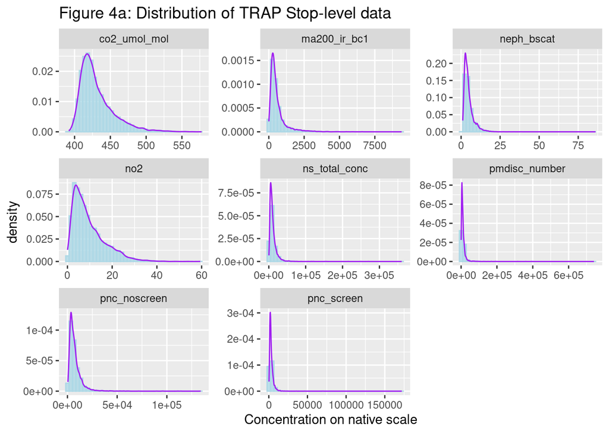

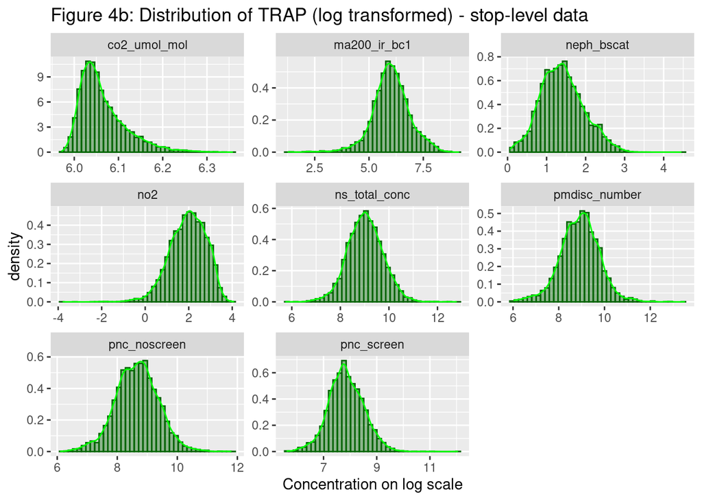

These histograms further the point of the Q-Q plot. In our introduction of this data in the term paper we will choose either the histograms or the Q-Q plots, and either the log-transformed or native scale variables to report.

**Seasonal Evaluation of the TRAP variables concentrations:**

The stop-level data provided the date and week of the year that each sample was taken. To look at seasonal changes in the stop-level TRAP data, we need to separate the weeks of the year into four seasons. We did this by breaking up the roughly 52 weeks of the year into 4, ~13-week segments.

Weeks 13 - 25 of the year are coded as spring weeks 26 - 38 are coded as summer weeks 39 - 50 are coded as autumn and week 51,52 and 1-12 are coded as winter.

```
seasons$variable
       n  missing distinct
   60557        0        8

Value       co2_umol_mol  ma200_ir_bc1    neph_bscat           no2
Frequency           8950          7411          8776          8382
Proportion         0.148         0.122         0.145         0.138

Value      ns_total_conc pmdisc_number  pnc_noscreen    pnc_screen
Frequency           8808          5353          7792          5085
Proportion         0.145         0.088         0.129         0.084
```

Table 3.0: Seasonal Summary of stop-level TRAP variables

| variable | season | n | GM | GSD | AM | ASD |
| --- | --- | --- | --- | --- | --- | --- |
| co2_umol_mol | Spring | 2111 | 431.8 | 1.0 | 432.3 | 21.6 |
| co2_umol_mol | Summer | 2277 | 418.9 | 1.0 | 419.2 | 16.9 |
| co2_umol_mol | Autumn | 2100 | 439.1 | 1.1 | 439.9 | 26.5 |
| co2_umol_mol | Winter | 2462 | 432.3 | 1.1 | 432.9 | 23.2 |
| ma200_ir_bc1 | Spring | 2061 | 322.6 | 2.3 | 441.6 | 427.0 |
| ma200_ir_bc1 | Summer | 2273 | 378.3 | 2.1 | 491.4 | 413.2 |
| ma200_ir_bc1 | Autumn | 2126 | 574.9 | 2.4 | 823.9 | 778.6 |
| ma200_ir_bc1 | Winter | 951 | 394.1 | 2.5 | 591.2 | 669.4 |
| neph_bscat | Spring | 2085 | 3.8 | 1.6 | 4.2 | 2.3 |
| neph_bscat | Summer | 2260 | 4.2 | 1.5 | 4.5 | 2.0 |
| neph_bscat | Autumn | 2140 | 5.1 | 1.9 | 6.2 | 4.4 |
| neph_bscat | Winter | 2291 | 3.5 | 1.8 | 4.2 | 3.0 |
| no2 | Spring | 2092 | 5.7 | 2.3 | 7.8 | 6.6 |
| no2 | Summer | 2227 | 5.8 | 2.2 | 7.6 | 5.6 |
| no2 | Autumn | 2124 | 9.8 | 1.9 | 11.8 | 6.7 |
| no2 | Winter | 1939 | 8.0 | 2.4 | 11.2 | 8.5 |
| ns_total_conc | Spring | 2088 | 7237.2 | 1.9 | 9271.2 | 11795.9 |
| ns_total_conc | Summer | 2299 | 8249.4 | 1.8 | 10034.8 | 8783.5 |
| ns_total_conc | Autumn | 2141 | 8986.4 | 2.0 | 11756.7 | 11025.7 |
| ns_total_conc | Winter | 2280 | 8697.3 | 2.4 | 12245.4 | 11465.2 |
| pmdisc_number | Spring | 246 | 5110.8 | 2.2 | 9415.3 | 47189.7 |
| pmdisc_number | Summer | 1121 | 7702.5 | 2.1 | 10369.1 | 15328.1 |
| pmdisc_number | Autumn | 2089 | 8154.5 | 2.2 | 11661.4 | 16508.5 |
| pmdisc_number | Winter | 1897 | 6835.6 | 2.6 | 10611.3 | 12399.8 |
| pnc_noscreen | Spring | 1569 | 5024.5 | 1.9 | 6253.4 | 5336.5 |
| pnc_noscreen | Summer | 2253 | 5928.1 | 1.9 | 7254.8 | 5542.4 |
| pnc_noscreen | Autumn | 2140 | 6488.0 | 2.0 | 8366.9 | 7921.5 |
| pnc_noscreen | Winter | 1830 | 5299.0 | 2.3 | 7452.8 | 6897.2 |
| pnc_screen | Spring | 1649 | 2200.3 | 2.0 | 2873.9 | 4954.2 |
| pnc_screen | Summer | 2234 | 2622.6 | 1.8 | 3120.0 | 2132.0 |
| pnc_screen | Autumn | 1202 | 3053.9 | 2.0 | 3943.5 | 3231.5 |

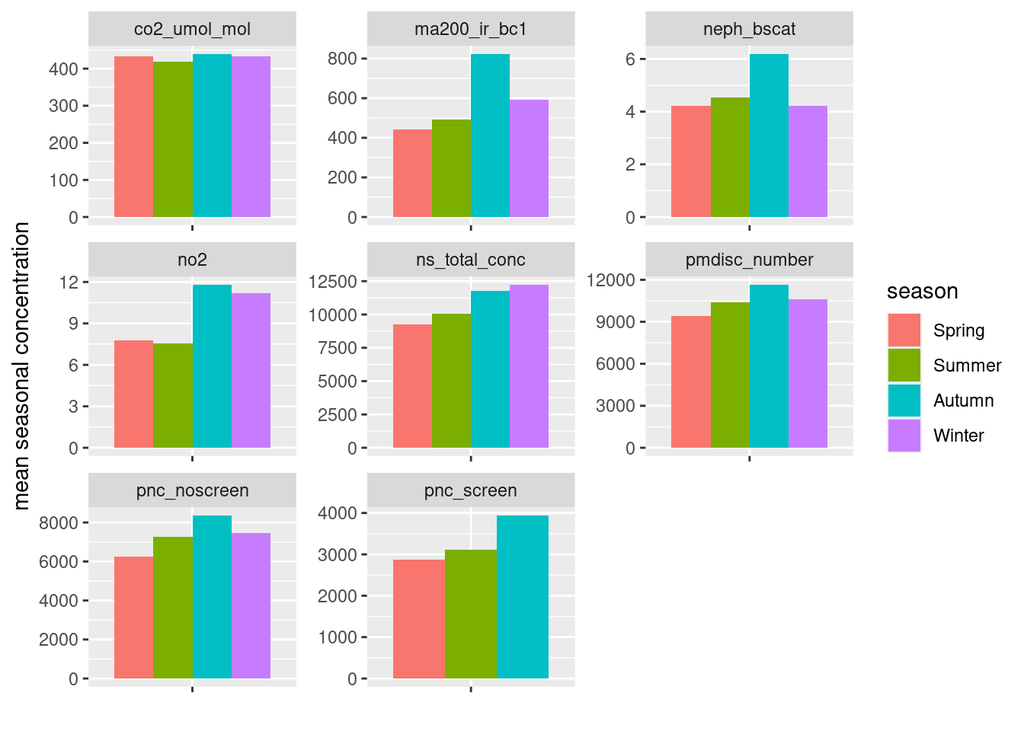

**Weekday Stratification and Summary of TRAP variables**

Table 3.0: Weekly Summary of stop-level TRAP variables

| variable | week_day | n | GM | GSD | AM | ASD |
| --- | --- | --- | --- | --- | --- | --- |
| co2_umol_mol | Friday | 1117 | 429.0 | 1.1 | 429.6 | 22.8 |
| co2_umol_mol | Monday | 1270 | 432.0 | 1.1 | 432.5 | 22.1 |
| co2_umol_mol | Saturday | 1246 | 427.2 | 1.0 | 427.7 | 20.9 |
| co2_umol_mol | Sunday | 1391 | 426.2 | 1.0 | 426.6 | 18.6 |
| co2_umol_mol | Thursday | 1387 | 435.1 | 1.1 | 435.9 | 27.5 |
| co2_umol_mol | Tuesday | 1281 | 430.9 | 1.1 | 431.7 | 26.7 |
| co2_umol_mol | Wednesday | 1258 | 431.6 | 1.1 | 432.2 | 22.7 |
| ma200_ir_bc1 | Friday | 969 | 421.4 | 2.2 | 585.1 | 554.8 |
| ma200_ir_bc1 | Monday | 1079 | 451.1 | 2.1 | 593.3 | 542.4 |
| ma200_ir_bc1 | Saturday | 938 | 315.7 | 2.6 | 467.0 | 486.7 |
| ma200_ir_bc1 | Sunday | 1126 | 314.0 | 2.1 | 402.7 | 312.6 |
| ma200_ir_bc1 | Thursday | 1139 | 468.2 | 2.6 | 719.3 | 734.5 |
| ma200_ir_bc1 | Tuesday | 1129 | 479.9 | 2.5 | 728.0 | 834.6 |
| ma200_ir_bc1 | Wednesday | 1031 | 447.6 | 2.1 | 582.9 | 462.4 |
| neph_bscat | Friday | 1117 | 4.0 | 1.6 | 4.6 | 3.0 |
| neph_bscat | Monday | 1267 | 4.2 | 1.6 | 4.8 | 2.8 |
| neph_bscat | Saturday | 1177 | 3.7 | 1.8 | 4.4 | 2.7 |
| neph_bscat | Sunday | 1351 | 3.8 | 1.7 | 4.4 | 2.5 |
| neph_bscat | Thursday | 1350 | 4.4 | 1.8 | 5.4 | 4.5 |
| neph_bscat | Tuesday | 1298 | 4.2 | 1.8 | 4.9 | 3.1 |
| neph_bscat | Wednesday | 1216 | 4.3 | 1.7 | 4.9 | 2.8 |
| no2 | Friday | 992 | 7.4 | 2.2 | 9.5 | 6.3 |
| no2 | Monday | 1156 | 8.4 | 2.2 | 10.7 | 6.8 |
| no2 | Saturday | 1208 | 5.5 | 2.2 | 7.4 | 6.4 |
| no2 | Sunday | 1311 | 5.0 | 2.1 | 6.4 | 4.7 |
| no2 | Thursday | 1277 | 8.4 | 2.3 | 11.5 | 8.3 |
| no2 | Tuesday | 1215 | 7.8 | 2.2 | 10.4 | 7.5 |
| no2 | Wednesday | 1223 | 8.4 | 2.2 | 11.0 | 7.6 |
| ns_total_conc | Friday | 1072 | 8379.2 | 2.0 | 10832.9 | 11309.2 |
| ns_total_conc | Monday | 1239 | 8596.5 | 2.0 | 11104.6 | 11670.6 |
| ns_total_conc | Saturday | 1206 | 6206.9 | 2.1 | 8286.1 | 8434.4 |
| ns_total_conc | Sunday | 1364 | 6628.3 | 1.9 | 8004.5 | 5689.4 |
| ns_total_conc | Thursday | 1396 | 9785.2 | 2.1 | 12719.0 | 12089.9 |
| ns_total_conc | Tuesday | 1269 | 9179.2 | 2.1 | 12244.2 | 11126.2 |
| ns_total_conc | Wednesday | 1262 | 9900.5 | 2.0 | 12632.9 | 13015.8 |
| pmdisc_number | Friday | 614 | 7955.2 | 2.3 | 11397.8 | 12426.9 |
| pmdisc_number | Monday | 720 | 8360.0 | 2.3 | 12113.5 | 21522.5 |
| pmdisc_number | Saturday | 729 | 5169.8 | 2.4 | 7940.7 | 11535.4 |
| pmdisc_number | Sunday | 846 | 5381.5 | 2.2 | 7340.3 | 7364.8 |
| pmdisc_number | Thursday | 853 | 9291.3 | 2.3 | 13767.5 | 30784.7 |
| pmdisc_number | Tuesday | 744 | 9219.3 | 2.3 | 13443.4 | 15298.5 |
| pmdisc_number | Wednesday | 847 | 7823.7 | 2.2 | 10585.8 | 10287.4 |
| pnc_noscreen | Friday | 910 | 6012.6 | 1.9 | 7690.2 | 7246.9 |
| pnc_noscreen | Monday | 1066 | 6360.6 | 2.0 | 8045.5 | 7325.3 |
| pnc_noscreen | Saturday | 1082 | 4201.3 | 2.0 | 5586.9 | 5623.2 |
| pnc_noscreen | Sunday | 1255 | 4504.7 | 1.9 | 5579.4 | 4129.1 |
| pnc_noscreen | Thursday | 1223 | 6819.3 | 2.0 | 8507.7 | 6889.6 |
| pnc_noscreen | Tuesday | 1152 | 6597.4 | 2.1 | 8777.0 | 8106.1 |
| pnc_noscreen | Wednesday | 1104 | 6276.3 | 2.0 | 7756.1 | 5472.5 |
| pnc_screen | Friday | 616 | 2154.7 | 1.9 | 2745.6 | 3412.6 |
| pnc_screen | Monday | 693 | 2753.5 | 1.8 | 3349.3 | 2875.9 |
| pnc_screen | Saturday | 620 | 1855.5 | 2.0 | 2427.1 | 2218.2 |
| pnc_screen | Sunday | 831 | 2418.1 | 1.7 | 2774.8 | 1715.3 |
| pnc_screen | Thursday | 836 | 3016.0 | 2.1 | 4022.1 | 6475.0 |
| pnc_screen | Tuesday | 825 | 2715.8 | 1.9 | 3421.6 | 2701.4 |
| pnc_screen | Wednesday | 664 | 3128.6 | 1.8 | 3676.4 | 2190.2 |

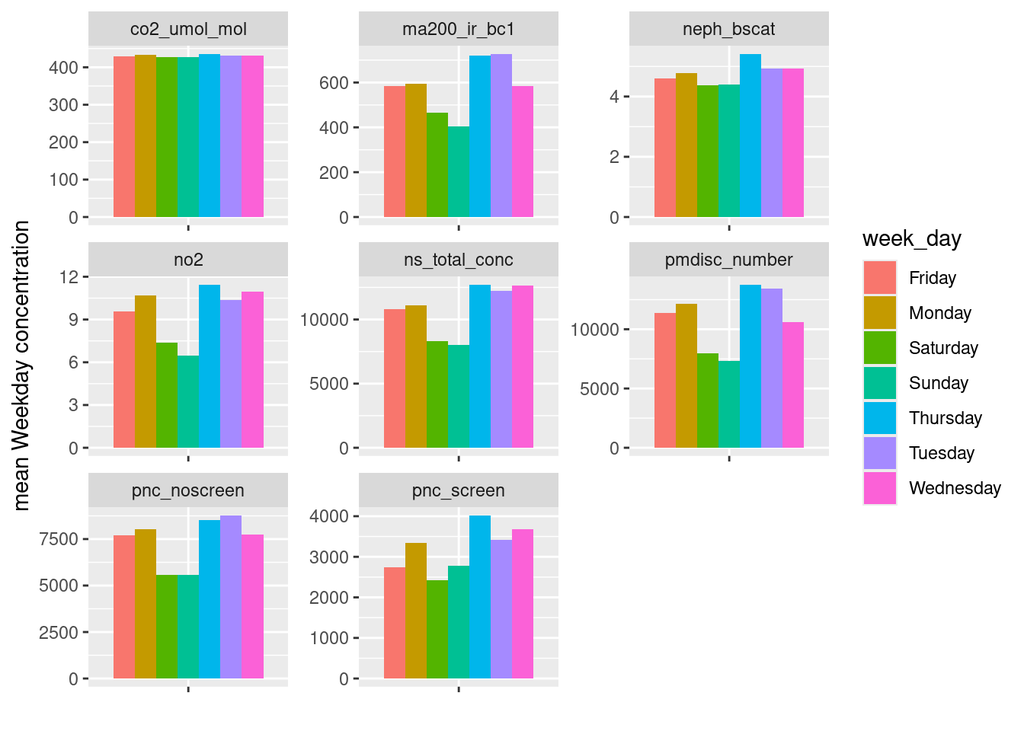

It looks like BC, PNC, NS, and NO2 may be lower on the weekends than the weekdays. This could point towards work week commuting contributions to TRAP concentrations.